# The Effects of BMI on Mortality

```r
# installing appropriate libraries
library(foreign)
library(ggplot2)
theme_set(theme_bw())
```

### Exploratory Data Analysis

```r
dat <- read.dta(file="framingham.dta")
paste0('number rows: ',nrow(dat),'; number columns: ',ncol(dat))
```

```
## [1] "number rows: 4434; number columns: 36"
```

```r
temp <- dat[,c("bmi","sex","age","death")]
dat <- dat[complete.cases(temp), ]
paste0('rows deleted: ',nrow(dat)-nrow(dat[complete.cases(temp), ] ))
```

```
## [1] "rows deleted: 0"
```

```r
dat$female <- dat$sex-1
tapply(dat$bmi, dat$female, summary)
```

```
## $`0`
##    Min. 1st Qu.  Median    Mean 3rd Qu.    Max.
##   15.54   23.97   26.08   26.17   28.32   40.38
##
## $`1`
##    Min. 1st Qu.  Median    Mean 3rd Qu.    Max.
##   15.96   22.54   24.83   25.59   27.82   56.80
```

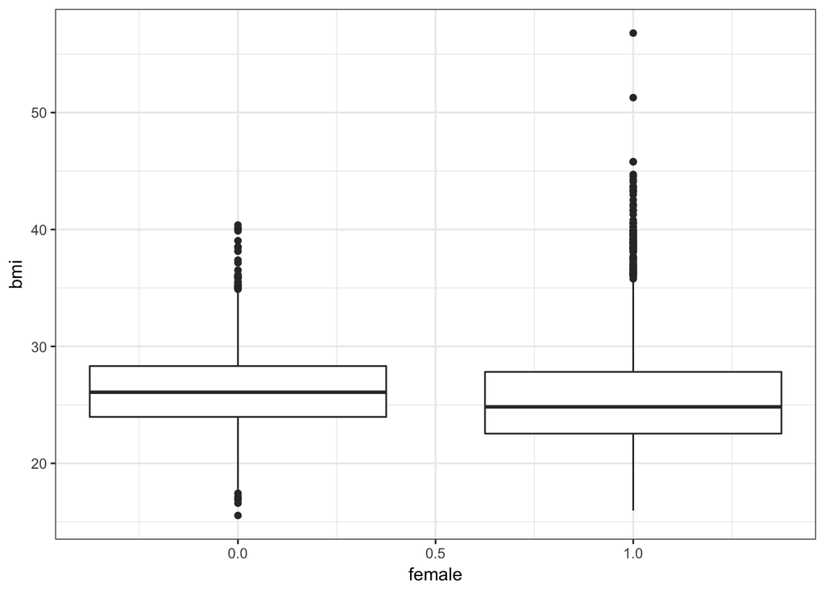

```r
ggplot(data = dat) + geom_boxplot(aes(female, bmi, group=female))
```

### Simple Logistic Regression

First, we start with a simple logistic regression model to assess the effects of BMI on mortality.

$$logit(mortality)=\beta_0+\beta_1bmi$$

```r
m1 <- glm(death~bmi, family=binomial(), data=dat)
summary(m1)
```

```
##
## Call:
## glm(formula = death ~ bmi, family = binomial(), data = dat)
##
## Deviance Residuals:
##     Min       1Q   Median       3Q      Max
## -1.5951  -0.9305  -0.8644   1.3969   1.6919
##
## Coefficients:
##              Estimate Std. Error z value Pr(>|z|)
## (Intercept) -1.949618   0.202824  -9.612  < 2e-16 ***
## bmi          0.050932   0.007686   6.627 3.42e-11 ***
## ---
## Signif. codes:  0 '***' 0.001 '**' 0.01 '*' 0.05 '.' 0.1 ' ' 1
##
## (Dispersion parameter for binomial family taken to be 1)
##
##     Null deviance: 5706.7  on 4414  degrees of freedom
## Residual deviance: 5662.4  on 4413  degrees of freedom
## AIC: 5666.4
##
## Number of Fisher Scoring iterations: 4
```

```r
ci <- exp(confint(m1)*5)[2,]
ci
```

```
##    2.5 %   97.5 %
## 1.196633 1.391253
```

The $\beta_1$ coefficient is statistically significant at the 0.05 significance level (p<0.05), indicating that there is a statistically significant association between mortality and BMI. The odds of mortality increase by $e^{0.050932}$ per one unit increase in BMI. We can then expand this to say that a 5-unit increase in BMI will raise the odds of mortality by $e^{0.050932*5}=1.29$. The confidence interval for this is $(1.197, 1.391)$.

### Non-Linear Effects

Next, we can evaluate if there are any nonlinear effects of BMI on the logit scale. To do this, we can add the linear and quadratic effects of BMI.

```r
dat$bmi2 <- (dat$bmi)^2
m2 <- glm(death~bmi+bmi2, family=binomial(), data=dat)
summary(m2)
```

```
##
## Call:
## glm(formula = death ~ bmi + bmi2, family = binomial(), data = dat)
##
## Deviance Residuals:
##     Min       1Q   Median       3Q      Max
## -1.7384  -0.9279  -0.8654   1.4006   1.6679
##
## Coefficients:
##               Estimate Std. Error z value Pr(>|z|)
## (Intercept) -1.6476413  0.7949050  -2.073   0.0382 *
## bmi          0.0287998  0.0568957   0.506   0.6127
## bmi2         0.0003947  0.0010062   0.392   0.6949
## ---
## Signif. codes:  0 '***' 0.001 '**' 0.01 '*' 0.05 '.' 0.1 ' ' 1
##
## (Dispersion parameter for binomial family taken to be 1)
##
##     Null deviance: 5706.7  on 4414  degrees of freedom
## Residual deviance: 5662.2  on 4412  degrees of freedom
## AIC: 5668.2
##
## Number of Fisher Scoring iterations: 4
```

```r
# odds ratios
odds20=exp(-1.6476413+0.0287998*20+0.0003947*20^2)
odds25=exp(-1.6476413+0.0287998*25+0.0003947*25^2)
odds30=exp(-1.6476413+0.0287998*30+0.0003947*30^2)
odds35=exp(-1.6476413+0.0287998*35+0.0003947*35^2)
or1=odds25/odds20
or2=odds35/odds30
print(c(or1,or2))
```

```
## [1] 1.262137 1.312950
```

From the output of the model, we can estimate some odds ratios - for example: the odds ratio for a 5-unit increase in BMI from 20 to 25 is 1.262, while the odds ratio for a 5-unit increase in BMI from 30 to 35 is 1.313. There is an expected difference in odds ratio estimates here since there is a quadratic BMI term in the model.

When adding the quadratic BMI term, the coefficients change (by more than 10%) and the BMI term is no longer statistically significant at the 0.05 signifiance level (p>.05). It seems like the quadratic BMI term is not necessary, since the BMI^2 coefficient is not statistically significant at the 0.05 level ($p=0.695$). From the plot, we can see that the models are quite similar, with the quadratic model being slightly more curved as expected.

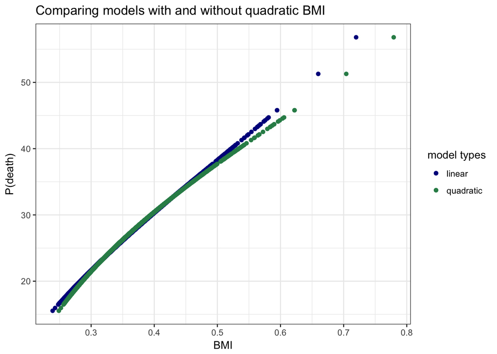

```r
ggplot(data = dat) +
  geom_point(aes(m1$fitted.values,dat$bmi, color = 'dark blue')) +
  geom_point(aes(m2$fitted.values,dat$bmi, color = 'seagreen')) +
  xlab('BMI') +
  ylab('P(death)') +
  ggtitle('Comparing models with and without quadratic BMI') +
  scale_color_manual(name = 'model types',
                     values = c('dark blue', 'seagreen'),
                     labels = c('linear','quadratic'))
```

## Gender as a confounder or effect modifier

```r
m3 <- glm(death~bmi+female,family=binomial(),data=dat)
summary(m3)
```

```
##
## Call:
## glm(formula = death ~ bmi + female, family = binomial(), data = dat)
##
## Deviance Residuals:
##     Min       1Q   Median       3Q      Max
## -1.4118  -0.9672  -0.7758   1.2936   1.8009
##
## Coefficients:
##              Estimate Std. Error z value Pr(>|z|)
## (Intercept) -1.513938   0.209687  -7.220 5.20e-13 ***
## bmi          0.047439   0.007798   6.084 1.18e-09 ***
## female      -0.644679   0.064299 -10.026  < 2e-16 ***
## ---
## Signif. codes:  0 '***' 0.001 '**' 0.01 '*' 0.05 '.' 0.1 ' ' 1
##
## (Dispersion parameter for binomial family taken to be 1)
##
##     Null deviance: 5706.7  on 4414  degrees of freedom
## Residual deviance: 5561.0  on 4412  degrees of freedom
## AIC: 5567
##
## Number of Fisher Scoring iterations: 4
```

```r
m4 <- glm(death~bmi+female+bmi*female,family=binomial(),data=dat)
summary(m4)
```

```
##
## Call:
## glm(formula = death ~ bmi + female + bmi * female, family = binomial(),
##     data = dat)
##
## Deviance Residuals:
##     Min       1Q   Median       3Q      Max
## -1.6777  -1.0453  -0.7592   1.2933   1.8866
##
## Coefficients:
##              Estimate Std. Error z value Pr(>|z|)
## (Intercept) -0.510089   0.355224  -1.436 0.151013
## bmi          0.009139   0.013453   0.679 0.496927
## female      -2.148473   0.436929  -4.917 8.78e-07 ***
## bmi:female   0.057502   0.016525   3.480 0.000502 ***
## ---
## Signif. codes:  0 '***' 0.001 '**' 0.01 '*' 0.05 '.' 0.1 ' ' 1
##
## (Dispersion parameter for binomial family taken to be 1)
##
##     Null deviance: 5706.7  on 4414  degrees of freedom
## Residual deviance: 5548.9  on 4411  degrees of freedom
## AIC: 5556.9
##
## Number of Fisher Scoring iterations: 4
```

The first model tested in this section, $logit(mortality)=\beta_0+\beta_1bmi+\beta_2I(female)$, indicates that sex is not a confounder of the effect of BMI on mortality. There is a $\frac{0.050932-0.047439}{0.050932}=0.069\to 6.9\%$ change in the BMI coefficient, which is very small. However, it does seem to be an effect modifier - the sex*BMI interaction term is statistically significant at the 0.05 significance level ($p=0.0005$).

## Age as a confounder or effect modifier

In this dataset, there are two variables related to age - a continuous and a categorical variable. To see which one to use, I fit a simple linear regression using each of these variables and compared them.

```r
m5 <- glm(death ~ age, family=binomial(), data=dat)
summary(m5)
```

```
##
## Call:
## glm(formula = death ~ age, family = binomial(), data = dat)
##
## Deviance Residuals:
##     Min       1Q   Median       3Q      Max
## -1.8143  -0.8389  -0.5579   0.9685   2.3053
##
## Coefficients:
##              Estimate Std. Error z value Pr(>|z|)
## (Intercept) -6.485989   0.231868  -27.97   <2e-16 ***
## age          0.114747   0.004409   26.03   <2e-16 ***
## ---
## Signif. codes:  0 '***' 0.001 '**' 0.01 '*' 0.05 '.' 0.1 ' ' 1
##
## (Dispersion parameter for binomial family taken to be 1)
##
##     Null deviance: 5706.7  on 4414  degrees of freedom
## Residual deviance: 4881.8  on 4413  degrees of freedom
## AIC: 4885.8
##
## Number of Fisher Scoring iterations: 4
```

```r
m6 <- glm(death ~ agecat, family=binomial(), data=dat)
summary(m6)
```

```
##
## Call:
## glm(formula = death ~ agecat, family = binomial(), data = dat)
##
## Deviance Residuals:
##     Min       1Q   Median       3Q      Max
## -1.5052  -0.6930  -0.6930   0.8818   2.2005
##
## Coefficients:
##             Estimate Std. Error z value Pr(>|z|)
## (Intercept) -3.35211    0.11926  -28.11   <2e-16 ***
## agecat       1.02406    0.04139   24.74   <2e-16 ***
## ---
## Signif. codes:  0 '***' 0.001 '**' 0.01 '*' 0.05 '.' 0.1 ' ' 1
##
## (Dispersion parameter for binomial family taken to be 1)
##
##     Null deviance: 5706.7  on 4414  degrees of freedom
## Residual deviance: 4966.7  on 4413  degrees of freedom
## AIC: 4970.7
##
## Number of Fisher Scoring iterations: 3
```

```r
m7 <- glm(death ~ as.factor(agecat), family=binomial(), data=dat)
summary(m7)
```

```
##
## Call:
## glm(formula = death ~ as.factor(agecat), family = binomial(),
##     data = dat)
##
## Deviance Residuals:
##     Min       1Q   Median       3Q      Max
## -1.5548  -0.6942  -0.6942   0.8422   2.1262
##
## Coefficients:
##                    Estimate Std. Error z value Pr(>|z|)
## (Intercept)         -2.1502     0.1387 -15.498  < 2e-16 ***
## as.factor(agecat)2   0.8499     0.1509   5.632 1.78e-08 ***
## as.factor(agecat)3   1.7881     0.1490  11.999  < 2e-16 ***
## as.factor(agecat)4   3.0042     0.1594  18.853  < 2e-16 ***
## ---
## Signif. codes:  0 '***' 0.001 '**' 0.01 '*' 0.05 '.' 0.1 ' ' 1
##
## (Dispersion parameter for binomial family taken to be 1)
##
##     Null deviance: 5706.7  on 4414  degrees of freedom
## Residual deviance: 4960.9  on 4411  degrees of freedom
## AIC: 4968.9
##
## Number of Fisher Scoring iterations: 4
```

```r
anova(m6, m7, test="Chisq")
```

```
## Analysis of Deviance Table
##
## Model 1: death ~ agecat
## Model 2: death ~ as.factor(agecat)
##   Resid. Df Resid. Dev Df Deviance Pr(>Chi)
## 1      4413     4966.7
## 2      4411     4960.9  2    5.857  0.05348 .
## ---
## Signif. codes:  0 '***' 0.001 '**' 0.01 '*' 0.05 '.' 0.1 ' ' 1
```

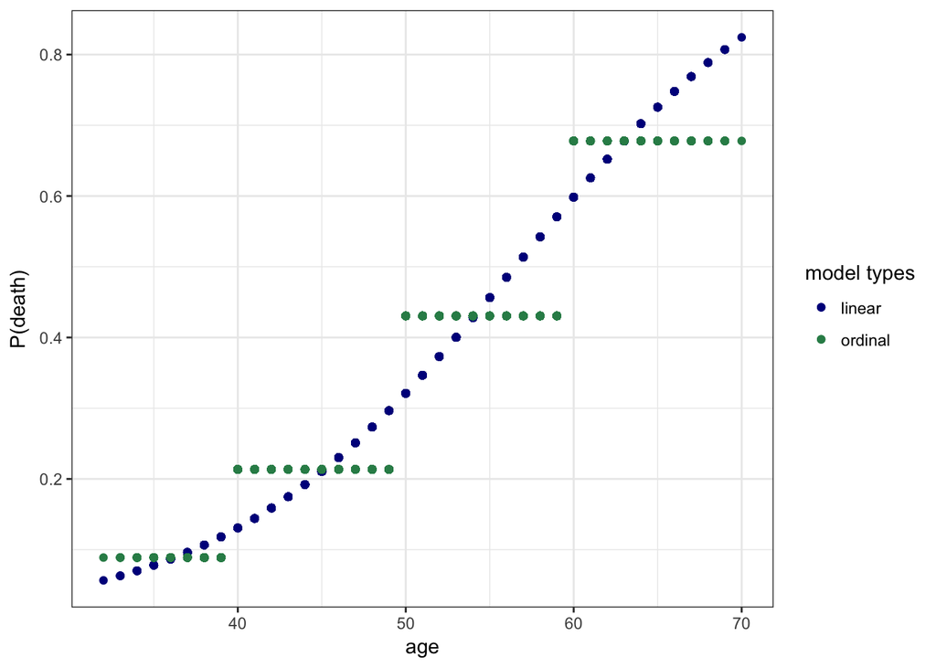

```r
ggplot() +
  geom_point(aes(dat$age,m5$fitted.values, color = 'dark blue')) +
  geom_point(aes(dat$age,m6$fitted.values, color = 'seagreen')) +
  xlab('age') +
  ylab('P(death)') +
  scale_color_manual(name = 'model types',
                     values = c('dark blue', 'seagreen'),
                     labels = c('linear','ordinal'))
```

From the likelihood ratio test between the `agecat` and categorical `agecat` models, we fail to reject the hypothesis that `agecat` is the preferred variable at the 0.05 signifiance level since $p=0.053$. Therefore, we conclude that the ordinal `agecat` model is preferred. Plotting the fitted values of the ordinal `agecat` model and the linear/continuous `age` model, the fitted values from the continuous `age` model seem to be a better fit.

For ease of interpretation, I used the categorical `agecat` variable to test for confounding and effect modification.

```r
m10 <- glm(death~bmi+as.factor(agecat),family=binomial(), data=dat)
summary(m10)
```

```
##
## Call:
## glm(formula = death ~ bmi + as.factor(agecat), family = binomial(),
##     data = dat)
##
## Deviance Residuals:
##     Min       1Q   Median       3Q      Max
## -1.7736  -0.7675  -0.6547   0.8791   2.2352
##
## Coefficients:
##                    Estimate Std. Error z value Pr(>|z|)
## (Intercept)        -2.91079    0.25486 -11.421  < 2e-16 ***
## bmi                 0.03025    0.00844   3.584 0.000339 ***
## as.factor(agecat)2  0.83656    0.15106   5.538 3.06e-08 ***
## as.factor(agecat)3  1.75306    0.14939  11.735  < 2e-16 ***
## as.factor(agecat)4  2.96480    0.15972  18.562  < 2e-16 ***
## ---
## Signif. codes:  0 '***' 0.001 '**' 0.01 '*' 0.05 '.' 0.1 ' ' 1
##
## (Dispersion parameter for binomial family taken to be 1)
##
##     Null deviance: 5706.7  on 4414  degrees of freedom
## Residual deviance: 4948.0  on 4410  degrees of freedom
## AIC: 4958
##
## Number of Fisher Scoring iterations: 4
```

```r
m11 <- glm(death~bmi*as.factor(agecat),family=binomial(), data=dat)
summary(m11)
```

```
##
## Call:
## glm(formula = death ~ bmi * as.factor(agecat), family = binomial(),
##     data = dat)
##
## Deviance Residuals:
##     Min       1Q   Median       3Q      Max
## -1.7561  -0.7788  -0.6487   0.8762   2.1551
##
## Coefficients:
##                         Estimate Std. Error z value Pr(>|z|)
## (Intercept)            -2.351735   0.921596  -2.552   0.0107 *
## bmi                     0.008057   0.036348   0.222   0.8246
## as.factor(agecat)2      0.159868   0.994433   0.161   0.8723
## as.factor(agecat)3      1.182847   0.990614   1.194   0.2325
## as.factor(agecat)4      2.469458   1.041398   2.371   0.0177 *
## bmi:as.factor(agecat)2  0.026758   0.039064   0.685   0.4934
## bmi:as.factor(agecat)3  0.022613   0.038821   0.582   0.5602
## bmi:as.factor(agecat)4  0.019770   0.040633   0.487   0.6266
## ---
## Signif. codes:  0 '***' 0.001 '**' 0.01 '*' 0.05 '.' 0.1 ' ' 1
##
## (Dispersion parameter for binomial family taken to be 1)
##
##     Null deviance: 5706.7  on 4414  degrees of freedom
## Residual deviance: 4947.5  on 4407  degrees of freedom
## AIC: 4963.5
##
## Number of Fisher Scoring iterations: 4
```

```r
anova(m10, m11, test="Chisq")
```

```
## Analysis of Deviance Table
##
## Model 1: death ~ bmi + as.factor(agecat)
## Model 2: death ~ bmi * as.factor(agecat)
##   Resid. Df Resid. Dev Df Deviance Pr(>Chi)
## 1      4410     4948.0
## 2      4407     4947.5  3  0.49921   0.9191
```

```r
oddsage1 = exp(-2.91079+0.03025)
oddsage2 = exp(-2.91079+0.03025 + 0.83656)
oddsage3 = exp(-2.91079+0.03025 + 1.75306)
oddsage4 = exp(-2.91079+0.03025 + 2.96480)
print(c(oddsage1, oddsage2, oddsage3, oddsage4))
```

```
## [1] 0.05610446 0.12951223 0.32384833 1.08791171
```

## The final model fit

$$logit(mortality) = \beta_0+\beta_1bmi+\beta_2I(agecat=2)+\beta_3I(agecat=3)+\beta_4I(agecat=4) + \beta_5I(female) + \beta_6I(female)*bmi$$

```r
m12 <- glm(death~bmi + as.factor(agecat) + female + bmi*female,family=binomial(), data=dat)
summary(m12)
```

```
##
## Call:
## glm(formula = death ~ bmi + as.factor(agecat) + female + bmi *
##     female, family = binomial(), data = dat)
##
## Deviance Residuals:
##     Min       1Q   Median       3Q      Max
## -1.8028  -0.8486  -0.5569   0.9753   2.4158
##
## Coefficients:
##                    Estimate Std. Error z value Pr(>|z|)
## (Intercept)        -2.27361    0.41643  -5.460 4.77e-08 ***
## bmi                 0.01993    0.01487   1.340   0.1801
## as.factor(agecat)2  0.87420    0.15256   5.730 1.00e-08 ***
## as.factor(agecat)3  1.84008    0.15141  12.153  < 2e-16 ***
## as.factor(agecat)4  3.08161    0.16279  18.929  < 2e-16 ***
## female             -1.09045    0.48268  -2.259   0.0239 *
## bmi:female          0.01050    0.01828   0.574   0.5657
## ---
## Signif. codes:  0 '***' 0.001 '**' 0.01 '*' 0.05 '.' 0.1 ' ' 1
##
## (Dispersion parameter for binomial family taken to be 1)
##
##     Null deviance: 5706.7  on 4414  degrees of freedom
## Residual deviance: 4813.6  on 4408  degrees of freedom
## AIC: 4827.6
##
## Number of Fisher Scoring iterations: 4
```

From the final model, we can conclude that BMI does not have a statistically significant effect on mortality, adjusted for gender and categorical age.